### scotch whiskies flavour mapping with PCA

```
library(psych)
library(ggplot2)
library(gridExtra)

psych：多變量, 主成份, 因子, 可靠性分析等工具套件
ggplot2：繪圖及空間可視化
gridExtra：繪圖排列功能套件
```

延續 k-means cluster analysis of scotch whiskies 的主題，這次的目標是希望利用 PCA(Principal Component Analysis) 來建立 whiskies flavour map，使用的資料集 whisky.groups 為前次 K-means 分群後的 output，共86筆，18個變數欄位，包括流水編號(RowID)、蒸餾廠名稱(Distillery)、威士忌風味(3至14欄:Body, Sweetness, Smoky, Medicinal, Tobacco, Honey, Spicy, Winey, Nutty, Malty, Fruity, Floral)、郵遞區號(Postcode)、緯度(Latitude)、經度(Longitude)及群集編號(Groups)。首先從 whisky.groups 取出威士忌風味(3至14欄)作為後續 PCA 使用…

```r
# whisky.flavour
whisky.flavour  <- whisky.groups[, c(3:14)]
row.names(whisky.flavour) <- whisky.groups$Distillery
```

PCA 用途廣、可用在 dimensionality reduction, feature extraction, outlier detection …等，不過在使用之前先看看資料是否適合使用 PCA

1. 檢測資料適用性：2種參考做法…
- MSA (Measure of Sampling Adequacy)：檢測變數間的平均相關。使用 psych 套件的 KMO，執行結果 Overall MSA = 0.7，這結果算是中等，MSA 值越高越好，若是低於0.5則不被接受，表示變數間沒有足夠相關，對於維度減少(使用 PCA )沒有意義。除了 Overall MSA，還有每個變數的 MSA，刪除一些最低 MAS 的變數，可改善 Overall MSA …

```r
KMO(cor(whisky.flavour, use = "pairwise.complete.obs"))
```

```
## Kaiser-Meyer-Olkin factor adequacy
## Call: KMO(r = cor(whisky.flavour, use = "pairwise.complete.obs"))
## Overall MSA =  0.7
## MSA for each item =
##      Body Sweetness     Smoky Medicinal   Tobacco     Honey     Spicy
##      0.64      0.72      0.74      0.78      0.77      0.69      0.49
##     Winey     Nutty     Malty    Fruity    Floral
##      0.57      0.73      0.64      0.59      0.77
```

- Bartlett test：檢測變數間是否有統計關係。這個 test 假設變數間是獨立的( Null-hypothesis )，執行結果 p.value = 1.061041e-32，相當的小、趨近0，表示 correlation matrix 與 identity matrix 有顯著的不同，變數之間是有關聯的( Reject the null-hypothesis )，資料可以使用PCA

```r
cortest.bartlett(cor(whisky.flavour), n = 100)
```

```
## $chisq
## [1] 306.6863
##
## $p.value
## [1] 1.061041e-32
##
## $df
## [1] 66
```

簡單來說，Overall MSA 越高 或 p.value 越小，表示資料適合使用 PCA

2. 決定最佳 components 數量：3種參考做法…
- Kaiser criterion：經驗法則，留下標準差大於1者。執行結果有4個…若保留這4個 components， 表示大概可解釋原始變數約0.61579，也可利用 psych 套件的 VSS.scree 幫助可視化，它會在 eigen values(標準差的平方) = 1.0 繪出水平線，在水平線以上者即是可以決定的 components 數量

```r
summary(prcomp(whisky.flavour, scale = TRUE))
```

```
## Importance of components:
##                           PC1    PC2    PC3     PC4     PC5     PC6
## Standard deviation     1.7992 1.3829 1.0968 1.01828 0.97886 0.91625
## Proportion of Variance 0.2698 0.1594 0.1003 0.08641 0.07985 0.06996
## Cumulative Proportion  0.2698 0.4291 0.5294 0.61579 0.69564 0.76560
##                            PC7     PC8     PC9   PC10   PC11    PC12
## Standard deviation     0.88534 0.80493 0.68547 0.6312 0.5288 0.48291
## Proportion of Variance 0.06532 0.05399 0.03916 0.0332 0.0233 0.01943
## Cumulative Proportion  0.83092 0.88491 0.92406 0.9573 0.9806 1.00000
```

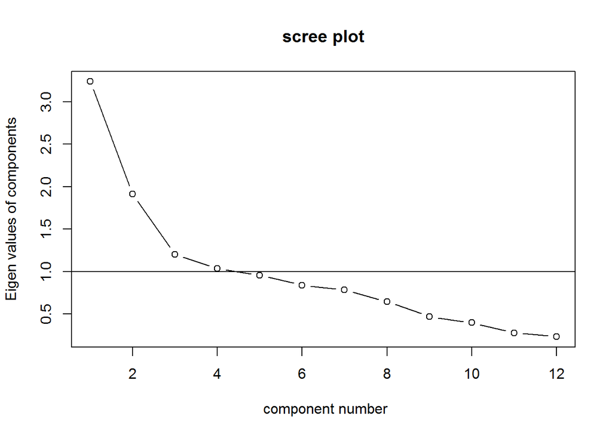

```r
VSS.scree(cor(whisky.flavour))
```

- Elbow-rule：線圖同手臂一般，急彎處的點即是最佳 components 數量。若利用此 rule 參考線圖，可以把 components 數量訂為3
- 利用有點隨機資料的抽樣手法來決定：使用 psych 套件的 fa.parallel，執行結果最佳 components 數量為2

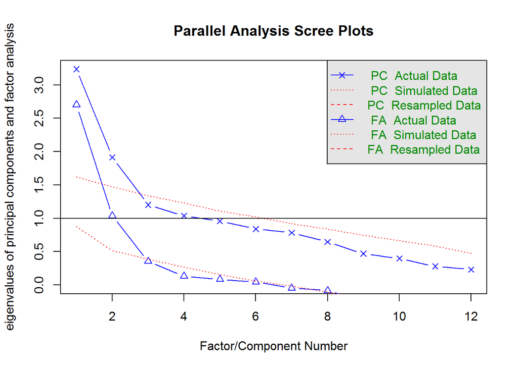

```
## Parallel analysis suggests that the number of factors =  2  and the number of components =  2
```

```r
fa.parallel(whisky.flavour)
```

以上三種參考做法建議值落在2 ~ 4，考量建立 whiskies flavour map 的目的，決定 keep 最佳 components 數量=2

3. 解釋 components
- 透過 rotation ( loadings ) 可以查看 component matrix，下圖顯示 PC1 主要包含了 Medicinal, Smoky, Tobacco, Body 等正向資訊和 Floral 等負向資訊，PC2 偏 Winey, Body, Honey, Nutty等負向資訊…

```r
pc <- prcomp(whisky.flavour, scale = TRUE)
pc$rotation[, 1:2]
```

```
##                   PC1         PC2
## Body       0.29299602 -0.48297574
## Sweetness -0.25104935  0.01157776
## Smoky      0.46413071 -0.14107035
## Medicinal  0.48689110  0.07595446
## Tobacco    0.30802734  0.04862369
## Honey     -0.24876270 -0.43135466
## Spicy      0.05492423 -0.26328418
## Winey     -0.05167427 -0.55204060
## Nutty     -0.06889636 -0.29901817
## Malty     -0.19801886 -0.19505799
## Fruity    -0.24698203 -0.15246900
## Floral    -0.36226838  0.16651032
```

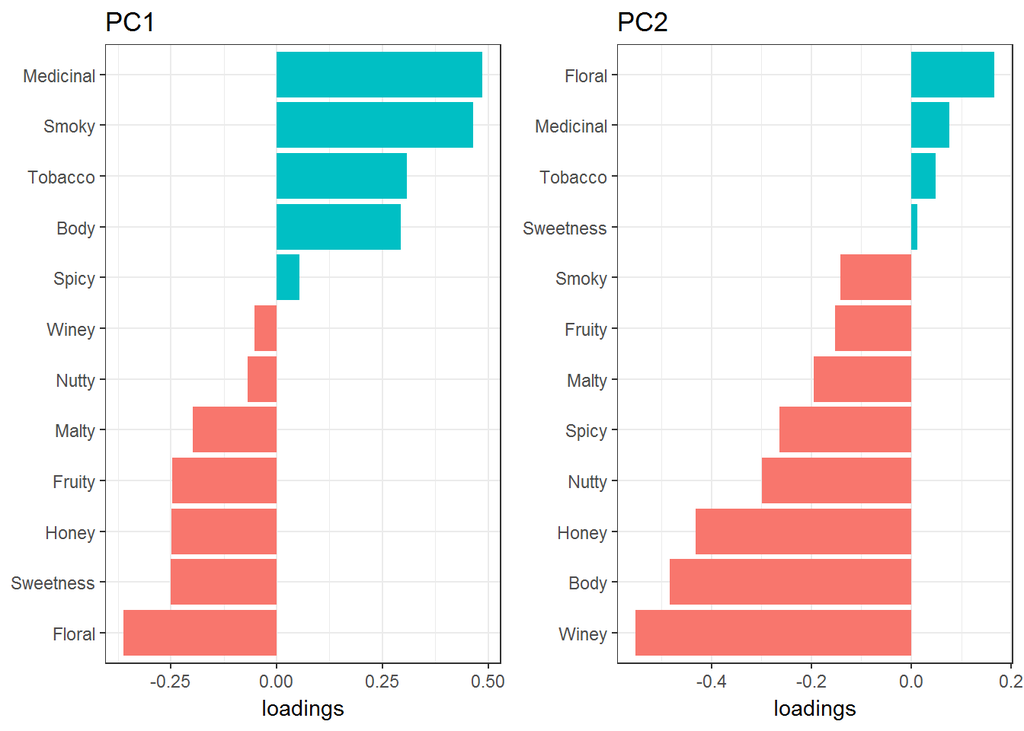

- biplot 可同時呈現觀測值(黑字部份)與原始變數資訊(紅字部份)在主要 components 座標上，提供視覺化輔助…

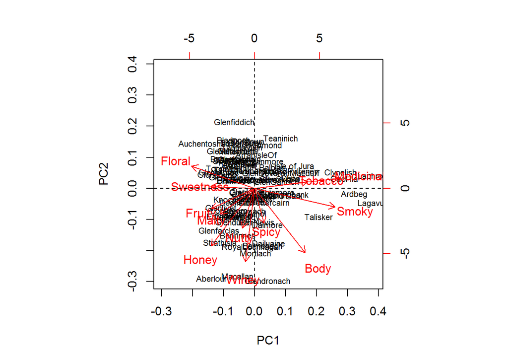

```r
biplot(pc, cex = c(0.7, 1))
abline(h = 0, v = 0, lty = 'dashed')
```

- varimax 透過正交旋轉( orthogonal rotation )方式，將 loadings matrix 變異數極大化，產生更容易解讀的分數

```r
(pcv <- varimax(pc$rotation[, 1:2])$loadings)
```

```
##
## Loadings:
##           PC1    PC2
## Body       0.330 -0.458
## Sweetness -0.251
## Smoky      0.474 -0.104
## Medicinal  0.479  0.114
## Tobacco    0.303
## Honey     -0.214 -0.450
## Spicy            -0.258
## Winey            -0.554
## Nutty            -0.304
## Malty     -0.182 -0.210
## Fruity    -0.234 -0.172
## Floral    -0.374  0.137
##
##                  PC1   PC2
## SS loadings    1.000 1.000
## Proportion Var 0.083 0.083
## Cumulative Var 0.083 0.167
```

根據以上，PC1 似乎主要受到煙燻藥水( Medicinal, Smoky )等氣味影響，與花香氣味( Floral )也成強烈對比，因此可以將 PC1 命名為 PEAT 成份，PC2 較不具體而且主要以負向居多，將其命名為 RICHNESS 成份

4. 建立 Whiskies Flavour Map

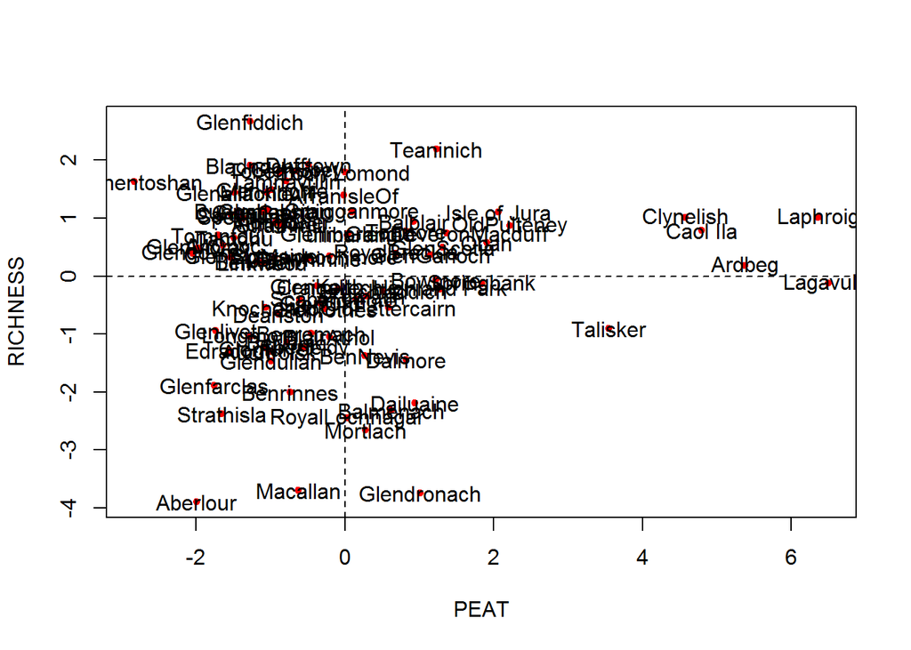

```r
whisky.pcv <- scale(whisky.flavour) %*% pcv
plot(whisky.pcv, type = 'p', xlab = 'PEAT', ylab = 'RICHNESS', col='red', pch=20)
text(whisky.pcv, labels = rownames(whisky.flavour))
abline(h = 0, v = 0, lty = 'dashed')
```

結合上次 K-means 分群 的主題加入 Groups 欄位並轉為 data frame，以 ggplot 繪出 Whiskies Flavour Map By Groups

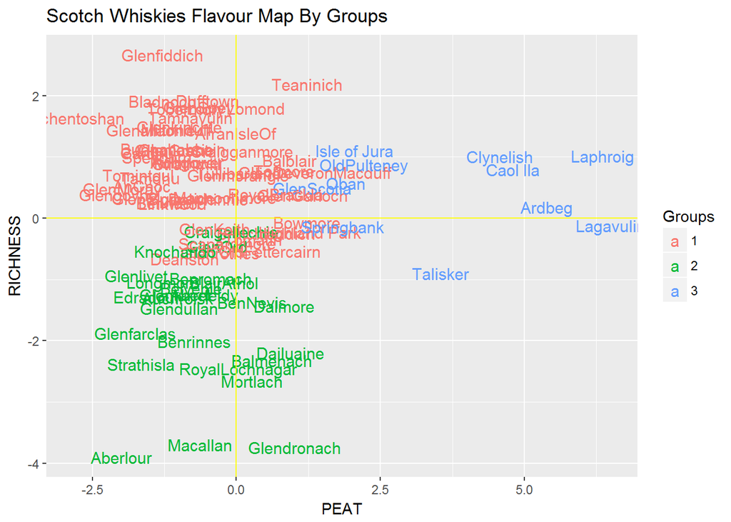

```r
# transfer df and add Groups col.
whisky.pcv <- transform(whisky.pcv, Groups=whisky.groups$Groups)
# plot
ggplot(whisky.pcv, aes(x=PC1, y=PC2, colour=Groups)) +
  geom_text(aes(label=rownames(whisky.pcv)), size=4) +
  labs(x = "PEAT", y = "RICHNESS", title = "Scotch Whiskies Flavour Map By Groups") +
  geom_hline(yintercept = 0, color ='yellow') +
  geom_vline(xintercept = 0, color ='yellow')
```

最後，透過 PCA 的方法，原始 whisky.flavour 的12個變數簡化成2個 components (PEAT, RICHNESS)，透過 Map 的確讓人更容易了解與解釋結果，不過由於資料本身的關係，簡化後的這2個 components 只解釋了原始變數的 0.4291…

### Lessons Learned:

#### Determining and interpreting components.